# Ford Go Bike Data Exploration

## by Michael Owusu Agyebeng

## Investigation Overview

> This data set is taken from https://www.fordgobike.com/system-data and represents trips taken by members of the service for month of February of 2019. I aim at exploring the variables that influence duration of these trips.

### What's the distribution of Duration of trips?

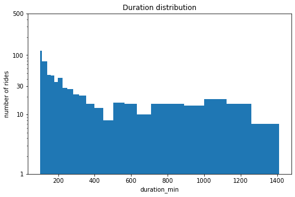

> Duration is a long-tailed right skewed distribution, with a lot of rides on the fewer minutes end, and close to none on the further right side. When plotted on a log-scale, the duration distribution still looks right skewed, with the peak between 0 and 100 minutes and also some increment between 1000 and 1200 minutes.

Next up, the first predictor variable of interest: Gender.

### What is the share of Gender in the data?

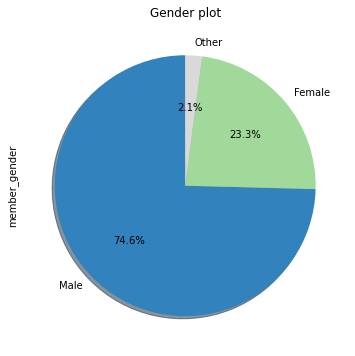

> In this case, gender was plotted on a pie chart and it revealed that almost 75% of the members were males, 23% females and 2% identified as another gender

Next up, the other predictor variable of interest: User Type.

### What is the percentage of Subscribers and Customers who went on trips?

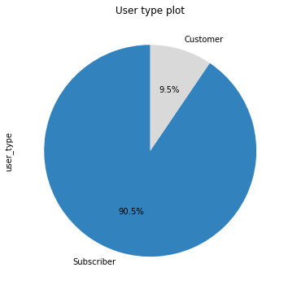

> 90.5% of the users are subsribers with only 9.5% being customers

### What is the Age distribution?

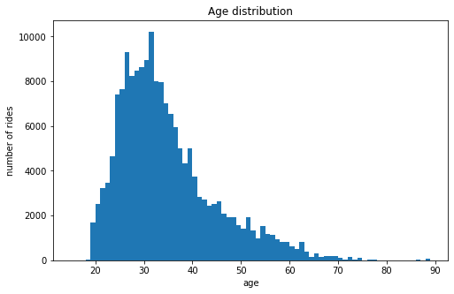

> Majority of the riders are between the ages of 20 and 40 and it is right skewed. With a few older people as well

### Relationship between age and Duration

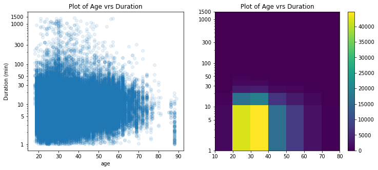

> From the plot, there is no clear relationship between Age and Duration of trips/ rides except that the graph tells us majority of the riders were young and almost all of them went for very short duration trips i.e, less than 30 minutes

### Highest times during the day user types go out for trips

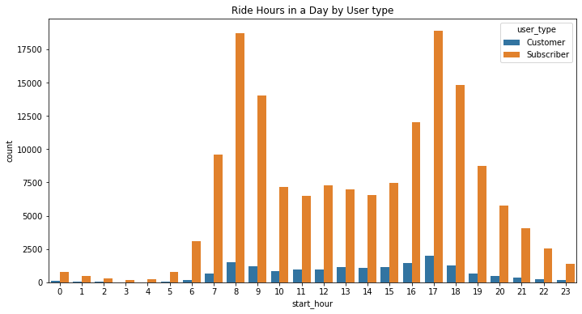

> It is obvious More subscribers went on rides than customers, also the distribution of the customers mimicked that of the subsribers in the senses that they also got peak rides at 8:00 and 17:00 and decreased when they decreased

### Gender and the times they go for bike rides

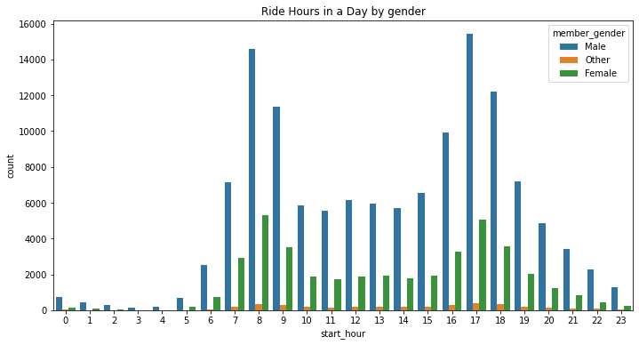

> Similarly, Male and Female distributions looked alike except for the huge variation in the number of rides by males

### Gender daily duration

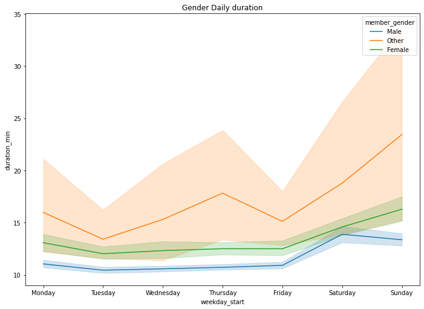

> Averagely, the Other gender had more duration for each day than Males and Females. This I believe is as a result of the huge number of males and females with a lot of the going for shorter durations. Also, there is a spike in duration for other and females on the weekends

### Gender Hourly duration

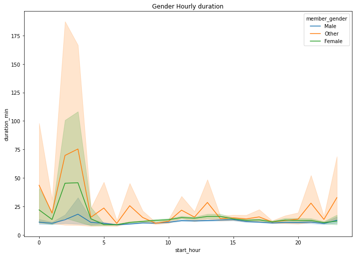

> Averagely, the longest lasting trips started at 2:00 am and 3:00 am with the other being showing its dominance. Also, Males average duration was particularly very stable and was the least at every time

## Conclusions

> Men turned out to be the gender with the most rides, however, its surprising to see that they rather had shorter rides compared to the other genders

> Also, Other gender, though it had the least of counts, turned out to be the gender that went for the longest trips

> The longest trips also started on the weekends, this could be as a result of majority of the agegroup being those of the working class so they are mostly availabe for longer trips on weekends